# bellabeat_report

Wei Su

2022-06-04

## Background

Bellabeat, a high-tech company that manufactures health-focused smart products. The company has asked the marketing analytics team to analyze smart device usage data in order to gain insight into how people are already using their smart devices. Then, using this information, she would like high-level recommendations for how these trends can inform Bellabeat marketing strategy.

## Questions to answer and objectives

Question: What is the relationship between sleep hours to activity level? Objective: Time window to push ads when users are likely planning to do exercise.

Question: Is in-bed time and actual asleep time the same? Objective: Time window to push ads when users are likely on their phone planning for the next day.

Question: What is the exercise level in each day of the week? Objective: To find out in what day of the week we should push ads to users?

Clear evidence is available that drinking during exercise can improve performance [link](https://onlinelibrary.wiley.com/doi/full/10.1111/j.1467-3010.2009.01790.x)

## Load packages

```r
setwd("D:/GDA/bellabeat")
library(tidyverse)
```

```r
library(ggplot2)
library(lubridate)
```

## Data Preperation

### Source

FitBit Fitness [Tracker Data](https://www.kaggle.com/arashnic/fitbit) (CC0: Public Domain, dataset made available through Mobius): This Kaggle data set contains personal fitness tracker from thirty fitbit users. Thirty eligible Fitbit users consented to the submission of personal tracker data, including minute-level output for physical activity, heart rate, and sleep monitoring. It includes information about daily activity, steps, and heart rate that can be used to explore users’ habits.

### Credibility

This is a public dataset available on the Kaggle platform provided by a single individual stating that this dataset contains data from thirty eligible Fitbit users consented to the submission of personal tracker data. This dataset is well known in the data science community and is widely used by other data science learners for practice purposes. In addition, this dataset was selected by the Google Analytics certificate course as the practice dataset for its final course capstone project.

### Data Limitations

- Small sample - This dataset only contains fitness tracking data from thirty users over a period of thirty data. It may not be representative of the wider population
- Not timely - The data is collected in 2016, may not be representative of today’s trend. Especially, given the lifestyle changes in the post-pandemic era.
- Too narrow - This dataset is missing other valuable data such as, sex, job, age, fitness goal, etc. This could lead to incomprehensive conclusion from the analysis.

## Data Processing

### Technology platforms

*Bigquery - for data storing and extraction* R and Rstudio - for data analysis and sepecifc data manipulation

### Data Cleaning

- Trim - to remove leading and ending spaces
- Data outliers - ran histogram to make sure there is no data outliers in the dataset
- Date conversions - for all hourly and by minute data tables, date time conversions needed to be performed. The objective was to convert the aggregated datetime field to date and time fields for integrity and ingestability.
- Null data points - ran null detection to unearth null data points and perform data manipulation accordingly.
- Data credibility - this dataset is relatively clean and comphrehensive, in that, there were minimum nulls and data outliers in the tables.

## Analyze

### Relationship between sleep hours and activity durations and activity levels

#### Objective

Sought to see how the amount of sleeping hours in the preceding night impact the level of activity today. This could provide insights to help predicting how likely a user will perform exercise in any given day.

#### The analysis

Loading joined table generated from Bigquery that contains the amount activity minutes and sleep hours by date.

```r
sleep_vs_activity <- read.csv('Data/Fitabase Data 4.12.16-5.12.16/generated/sleep_vs_activity.csv')
```

Sleep Hours vs. Activity Levels plot

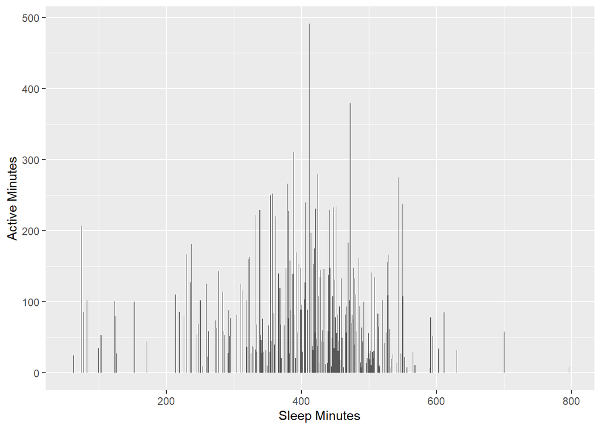

```r
ggplot(data = sleep_vs_activity) + geom_col(mapping = aes(x = TotalMinutesAsleep, y = FairlyActiveMinutes+VeryActiveMinutes))+
  labs (x = 'Sleep Minutes', y = "Active Minutes", Fill = 'Activity Inten')
```

### Excercise type and Calories

#### Objective

To confirm and unearth correlation between exercises type/duration and calorie burn. This insight could be shared with Bellabeat users via guiding articles to increase company credibility. Also, this finding can suggest potential sport companies and products that Bellabeat could work with in a collaboration campaign to broaden the reach.

#### Analysis

The graph below plot calorie burn in relation to active duration in minutes. The data was joined from two tables using Bigquery. The data was further enhanced with categorization technique to four different exercise types based on the activity intensity level measures.

In the plot below, a possible trend is visible between exercise time and calorie burn, confirming our hypothesis. Reasonable clustering is also presented confirming correlation between calorie burn and exercise type. The clustering and domination of blue dots in the upper right region of the graph suggests that running is the most effective type of exercise in turns of calorie burn.

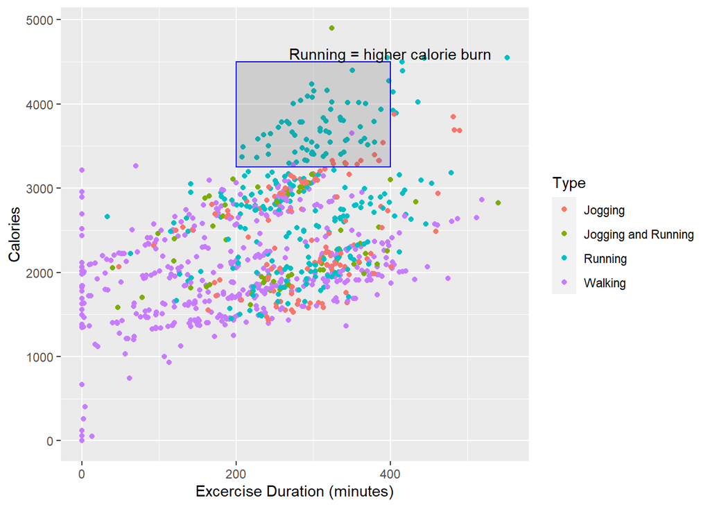

```r
da_et<-read.csv('Data/Fitabase Data 4.12.16-5.12.16/generated/da_excercise_type.csv')
ggplot(data = da_et) +
geom_point(mapping = aes(x = FairlyActiveMinutes+LightlyActiveMinutes+VeryActiveMinutes, y = Calories, color = Type))+
  labs(x = 'Excercise Duration (minutes)')+
  annotate("rect", xmin = 200, xmax = 400, ymin = 3250, ymax = 4500,alpha = .2, color = 'blue')+
  annotate('text', x = 400, y = 4600, label = 'Running = higher calorie burn')
```

#### Conclusion

The analysis above confirms correlation between exercises type/duration and calorie burn and revealed that running is a more efficient method of exercising in terms of calorie burn.

### When do users excercise

#### Objective

Find out the days in a week and time that users likely to exercise. This will provide insight on when and the type of ads Bellabeat should push to users for better conversion rate

##### Day of the week analysis

In this analysis, we sought to find out which day or days in the week users likely to exercise. In the plot below, it is clear that users tend to exercise and with longer duration on Tuesday, with the preceding Sunday and Monday being the low points of exercising in a week. Also, the different exercise intensity duration follow relatively the same trend. However, despite the obvious high and low points, the trend of exercising time is relatively steady from Tuesday to Satarday.

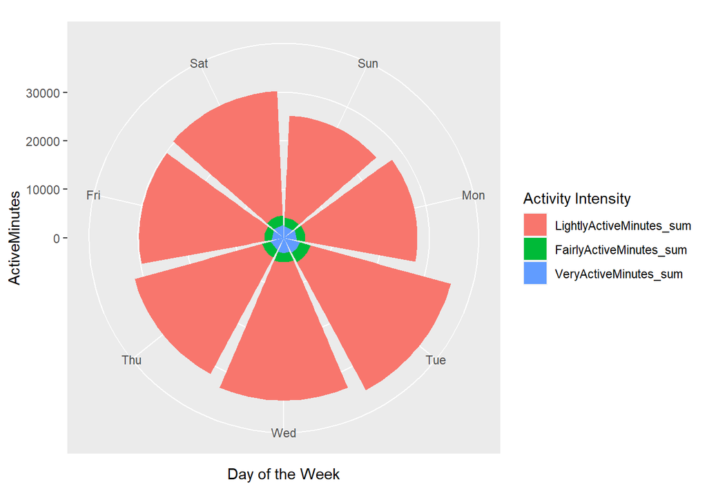

```r
da_et$weekday <- wday(da_et$ActivityDate, label=TRUE)
da_wdsum_wide<-da_et %>%
  group_by(weekday) %>%
  summarise(LightlyActiveMinutes_sum = sum(LightlyActiveMinutes),FairlyActiveMinutes_sum = sum(FairlyActiveMinutes),VeryActiveMinutes_sum = sum(VeryActiveMinutes) )
da_wdsum_long <- gather(da_wdsum_wide, Activity_intensity, ActiveMinutes, LightlyActiveMinutes_sum:VeryActiveMinutes_sum, factor_key=TRUE)
ggplot(data = da_wdsum_long) + geom_col(mapping = aes(x = weekday, y = ActiveMinutes, fill = Activity_intensity)) + coord_polar() +
  labs(x = 'Day of the Week', fill = 'Activity Intensity')
```

##### Excercise hour in a day

Similarly in this analysis the goal is to find out in which hour/hours in a day users tend to exercise more. The graph below shows the relationship between each hour in a day and the mean steps recorded. It shows that, 5pm-7pm is a time range with the most steps recorded. Alternatively, 12pm-2pm also shows clustering of high number of footsteps.

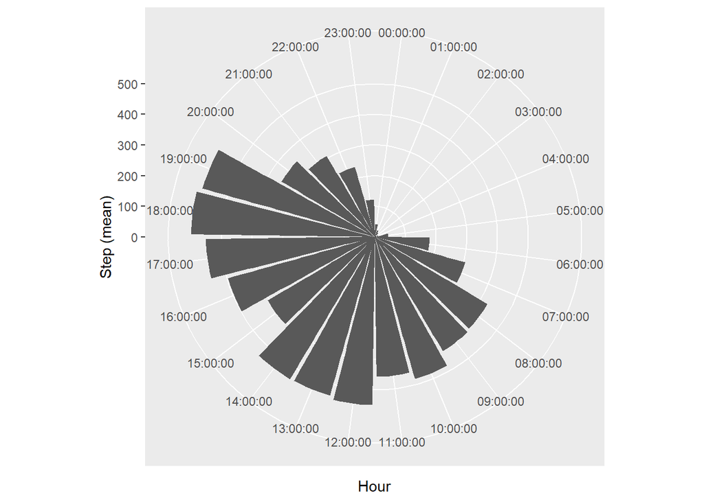

```r
hour_step_intensity <- read.csv('Data/Fitabase Data 4.12.16-5.12.16/generated/hour_step_intensity.csv')
hour_step_intensity [c('Date', 'Time_AMPM')] <- str_split_fixed(hour_step_intensity$ActivityHour, ' ', 2)
hour_step_intensity$Time_AMPM<-format(strptime(hour_step_intensity$Time_AMPM, "%I:%M:%S %p"), format="%H:%M:%S")
hour_step_intensity_gbHour <- hour_step_intensity %>%
  group_by(Time_AMPM) %>%
  summarise(Step_mean = mean(TotalStep), Intensity_mean = mean(TotalIntensity))
hour_step_intensity_long <- gather(hour_step_intensity_gbHour, type, mean, Step_mean:Intensity_mean, factor_key=TRUE)

ggplot(data = hour_step_intensity_gbHour) + geom_col(mapping = aes(x = Time_AMPM, y = Step_mean)) +
  labs(x = 'Hour', y='Step (mean)')+
coord_polar()
```

### In-bed time vs Asleep time

#### Objective

To see if there were differences between the recorded in-bed minutes and the asleep minutes. This insight may suggest new window for pushing ads to users when they are in bed planning for the next day.

#### Analysis

As shown in the graph below, the relationship between in-bed minutes and asleep minutes, while closely clustered together, it is not showing a straight upward slope, suggesting difference in the two measures. Further analysis confirmed that the average differences between in-bed minutes and asleep minutes is 39.17 minutes.

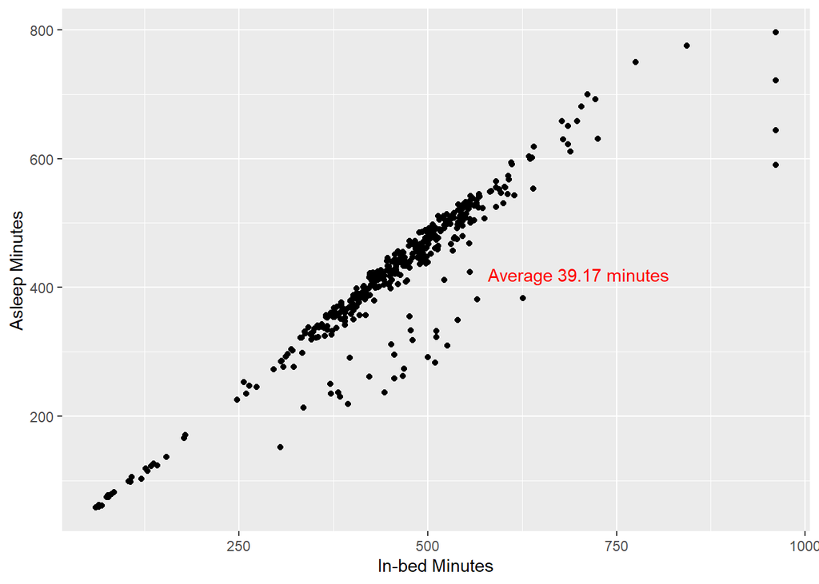

```r
sleep <- read.csv('Data/Fitabase Data 4.12.16-5.12.16/sleepDay_merged.csv')
sleep [c('Date', 'Time', 'AM/PM')] <- str_split_fixed(sleep$SleepDay, ' ', 3)
sleep$Date <- as.Date(sleep$Date,format='%m/%d/%Y')
ggplot(data = sleep) + geom_point(mapping = aes(x = TotalTimeInBed, y = TotalMinutesAsleep)) +
  labs(x = "In-bed Minutes", y = 'Asleep Minutes') +
  annotate('text', x = 700, y = 420, label = 'Average 39.17 minutes', color = 'red')
```

```r
mean(sleep$TotalTimeInBed) - mean(sleep$TotalMinutesAsleep)
```

```
## [1] 39.17191
```

#### Conclusion

In this analysis, we learned that users stay up for another 39 minutes in bed before being actually asleep.

### Recommandations - Act

#### Share our findings to users

Share our findings on how insufficient/adequate sleep could impact users’ exercise patterns and the efficiency of different exercise methods in calorie burn to increase the credibility of Bellabeat.

#### Push ads to promote the Spring product after exercise

Clear evidence is available that drinking during exercise can improve performance [link](https://onlinelibrary.wiley.com/doi/full/10.1111/j.1467-3010.2009.01790.x). We learned that 12pm-2pm and 5pm-7pm are the peak hours for exercise in a day. Therefore, we recommend reaching out to potential users about Spring right after these peak hours highlighting the importance of drinking during exercise and how it can improve performance, which Spring can help users to achieve.